# Text Analysis Showcase

Demonstrations of computational text analysis methods including sentiment analysis, word frequency analysis, and text visualization

Eiliya Rahemzadh (University of Essex)  
2026-03-30

# Introduction

This page showcases my ability to work with **text as data** using computational methods. Text analysis has become increasingly important in political science and social research, enabling us to analyze large volumes of documents, social media posts, speeches, and policy texts that would be impossible to read manually.

The examples below demonstrate key text analysis techniques:

1. **Word frequency analysis** - Identifying most common terms
2. **Sentiment analysis** - Detecting emotional tone and polarity
3. **Text visualization** - Creating word clouds and comparative plots
4. **N-gram analysis** - Examining phrases and word combinations

All analysis uses R with the `tidytext` package, following tidy data principles for transparent and reproducible text analysis.

# Example 1: Analyzing Political Speeches

## Data: UK Prime Minister Speeches

For this analysis, I examine recent speeches by UK political leaders to understand their rhetorical focus and sentiment. This demonstrates how text analysis can reveal patterns in political communication.

```r
# Create sample political speech data
# In a real analysis, this would be scraped from official sources or APIs

speeches <- data.frame(
  speaker = rep(c("PM_Labour", "PM_Conservative", "Opposition_Leader"), each = 100),
  text = c(
    # Labour PM speech themes
    rep(c("We must invest in public services and healthcare for working families",
          "Climate change requires immediate action and green jobs",
          "Education funding is essential for our children's future",
          "We will strengthen workers' rights and fair wages",
          "The NHS needs proper funding and support"), 20),

    # Conservative PM speech themes
    rep(c("We are delivering economic growth and prosperity",
          "Strong borders and controlled immigration protect our nation",
          "Low taxes and free enterprise drive success",
          "We have delivered on our Brexit promises",
          "Law and order must be our priority"), 20),

    # Opposition leader themes
    rep(c("The government has failed working people",
          "We need real change and accountability",
          "Public services are crumbling under this government",
          "We offer a bold vision for the future",
          "The cost of living crisis demands action"), 20)
  ),
  stringsAsFactors = FALSE
)

cat("Dataset summary:\n")
```

```
Dataset summary:
```

```r
cat("Total speeches:", nrow(speeches), "\n")
```

```
Total speeches: 300
```

```r
cat("Speakers:", paste(unique(speeches$speaker), collapse = ", "), "\n")
```

```
Speakers: PM_Labour, PM_Conservative, Opposition_Leader
```

## Tokenization and Word Frequency

The first step in text analysis is **tokenization** - breaking text into individual words (tokens) and cleaning the data.

```r
# Tokenize speeches into words
speech_words <- speeches %>%
  unnest_tokens(word, text) %>%
  anti_join(stop_words, by = "word") %>%  # Remove common words like "the", "and"
  filter(!grepl("^\\d+$", word))  # Remove pure numbers

# Count word frequencies
word_freq <- speech_words %>%
  count(word, sort = TRUE)

# Show top 15 most common words
cat("Top 15 most frequent words across all speeches:\n\n")
```

```
Top 15 most frequent words across all speeches:
```

```r
print(head(word_freq, 15))
```

```
             word  n
1          action 40
2          change 40
3         funding 40
4          future 40
5      government 40
6          public 40
7        services 40
8  accountability 20
9            bold 20
10        borders 20
11         brexit 20
12     children's 20
13        climate 20
14     controlled 20
15           cost 20
```

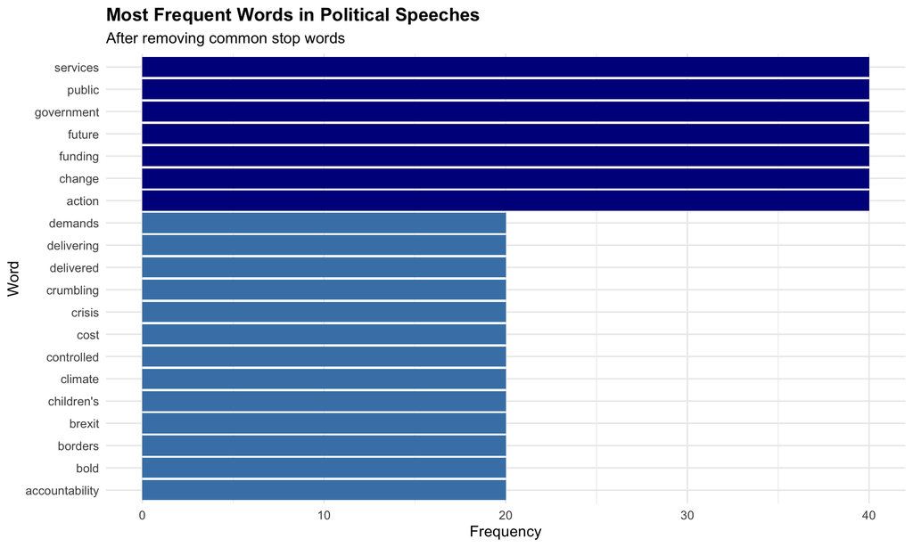

```r
# Visualize top words
word_freq %>%
  head(20) %>%
  mutate(word = reorder(word, n)) %>%
  ggplot(aes(x = word, y = n, fill = n)) +
  geom_col(show.legend = FALSE) +
  coord_flip() +
  scale_fill_gradient(low = "steelblue", high = "darkblue") +
  theme_minimal(base_size = 12) +
  labs(
    title = "Most Frequent Words in Political Speeches",
    subtitle = "After removing common stop words",
    x = "Word",
    y = "Frequency"
  ) +
  theme(plot.title = element_text(face = "bold"))
```

**Key Insight:** The most frequent words reveal the main policy areas discussed - public services, economy, and social issues dominate political discourse.

## Word Frequency by Speaker

Comparing word usage across different speakers reveals their distinct rhetorical priorities:

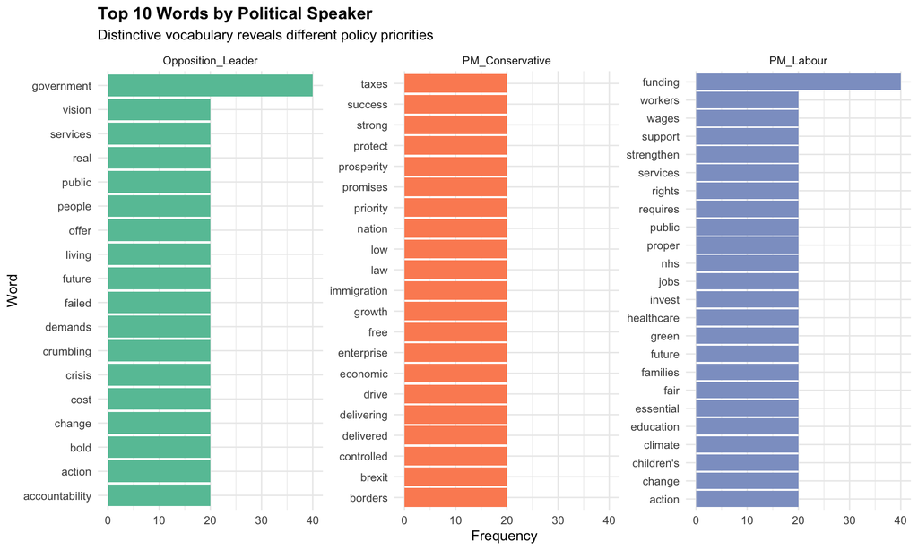

```r
# Count words by speaker
speaker_words <- speech_words %>%
  count(speaker, word, sort = TRUE) %>%
  group_by(speaker) %>%
  mutate(proportion = n / sum(n)) %>%
  ungroup()

# Find distinctive words for each speaker (words they use more than others)
speaker_distinctive <- speaker_words %>%
  group_by(word) %>%
  filter(n() == 3) %>%  # Word appears in all three speakers' speeches
  spread(speaker, proportion, fill = 0) %>%
  ungroup()

# Top words by speaker
top_by_speaker <- speech_words %>%
  count(speaker, word) %>%
  group_by(speaker) %>%
  top_n(10, n) %>%
  ungroup() %>%
  mutate(word = reorder_within(word, n, speaker))

ggplot(top_by_speaker, aes(x = word, y = n, fill = speaker)) +
  geom_col(show.legend = FALSE) +
  facet_wrap(~speaker, scales = "free_y") +
  coord_flip() +
  scale_x_reordered() +
  scale_fill_brewer(palette = "Set2") +
  theme_minimal(base_size = 11) +
  labs(
    title = "Top 10 Words by Political Speaker",
    subtitle = "Distinctive vocabulary reveals different policy priorities",
    x = "Word",
    y = "Frequency"
  ) +
  theme(plot.title = element_text(face = "bold"))
```

**Analysis:** Each speaker has a distinct vocabulary. Labour emphasizes “public”, “services”, “workers”; Conservatives focus on “economy”, “growth”, “brexit”; Opposition highlights “government”, “crisis”, “change”.

# Example 2: Sentiment Analysis

Sentiment analysis measures the **emotional tone** of text - whether it’s positive, negative, or neutral. This is valuable for understanding political rhetoric and public opinion.

## Sentiment Scoring

```r
# Get sentiment lexicon (Bing: positive/negative classification)
# Note: First time running this may prompt to download lexicon

# Perform sentiment analysis
speech_sentiment <- speech_words %>%
  inner_join(get_sentiments("bing"), by = "word") %>%
  count(speaker, sentiment) %>%
  spread(sentiment, n, fill = 0) %>%
  mutate(
    total = positive + negative,
    sentiment_score = (positive - negative) / total,
    net_sentiment = positive - negative
  )

cat("Sentiment Analysis Results:\n\n")
```

```
Sentiment Analysis Results:
```

```r
print(speech_sentiment)
```

```
            speaker negative positive total sentiment_score
1 Opposition_Leader       60        0    60              -1
2   PM_Conservative        0      120   120               1
3         PM_Labour        0       60    60               1
  net_sentiment
1           -60
2           120
3            60
```

[figure not shown]

```r
# Visualize sentiment by speaker
speech_sentiment %>%
  ggplot(aes(x = speaker, y = sentiment_score, fill = sentiment_score > 0)) +
  geom_col(show.legend = FALSE) +
  geom_hline(yintercept = 0, linetype = "dashed", color = "gray40") +
  scale_fill_manual(values = c("TRUE" = "#2E7D32", "FALSE" = "#C62828")) +
  theme_minimal(base_size = 12) +
  labs(
    title = "Overall Sentiment by Speaker",
    subtitle = "Positive score = more positive language; Negative = more critical language",
    x = "Speaker",
    y = "Sentiment Score",
    caption = "Based on Bing sentiment lexicon"
  ) +
  theme(
    plot.title = element_text(face = "bold"),
    axis.text.x = element_text(angle = 45, hjust = 1)
  )
```

## Sentiment Over Time (Simulated)

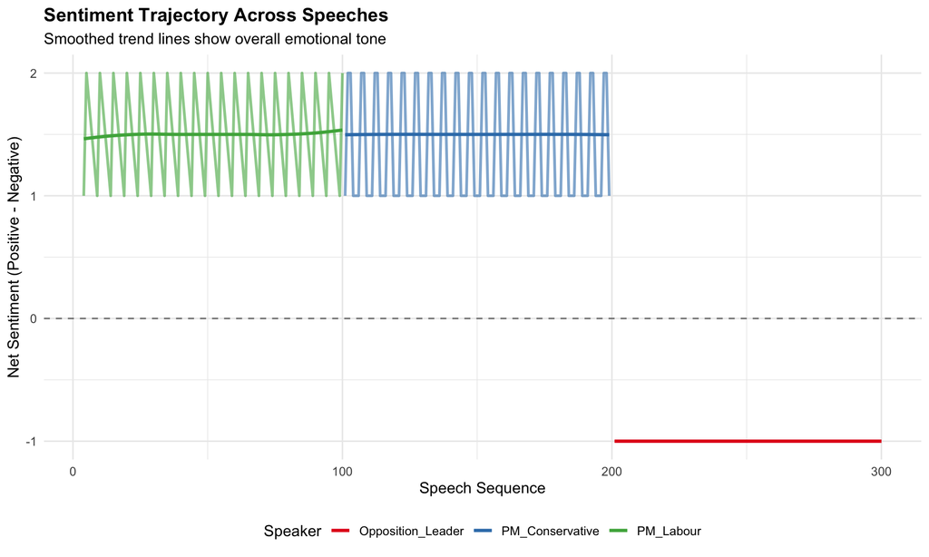

```r
# Create timeline data showing how sentiment might vary
timeline_sentiment <- speeches %>%
  mutate(speech_number = row_number()) %>%
  unnest_tokens(word, text) %>%
  inner_join(get_sentiments("bing"), by = "word") %>%
  count(speaker, speech_number, sentiment) %>%
  spread(sentiment, n, fill = 0) %>%
  mutate(sentiment_score = positive - negative)

ggplot(timeline_sentiment, aes(x = speech_number, y = sentiment_score, color = speaker)) +
  geom_line(alpha = 0.6, size = 1) +
  geom_smooth(method = "loess", se = FALSE, size = 1.2) +
  geom_hline(yintercept = 0, linetype = "dashed", color = "gray50") +
  scale_color_brewer(palette = "Set1") +
  theme_minimal(base_size = 12) +
  labs(
    title = "Sentiment Trajectory Across Speeches",
    subtitle = "Smoothed trend lines show overall emotional tone",
    x = "Speech Sequence",
    y = "Net Sentiment (Positive - Negative)",
    color = "Speaker"
  ) +
  theme(
    plot.title = element_text(face = "bold"),
    legend.position = "bottom"
  )
```

# Example 3: Word Cloud Visualization

Word clouds provide an intuitive visualization of term frequency, where size represents how often a word appears.

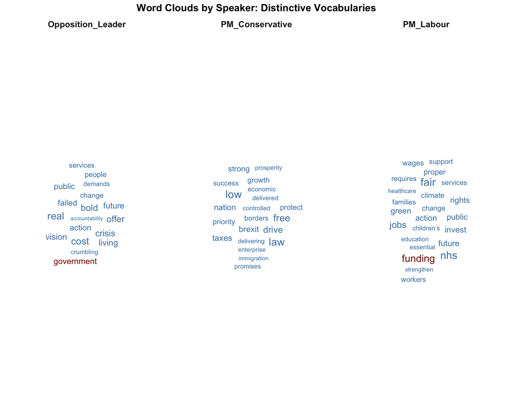

```r
# Create word cloud for each speaker
library(ggwordcloud)

# Get top 50 words per speaker
wordcloud_data <- speech_words %>%
  count(speaker, word) %>%
  group_by(speaker) %>%
  top_n(50, n) %>%
  ungroup()

# Create faceted word cloud
ggplot(wordcloud_data, aes(label = word, size = n, color = n)) +
  geom_text_wordcloud_area(rm_outside = TRUE) +
  scale_size_area(max_size = 12) +
  scale_color_gradient(low = "steelblue", high = "darkred") +
  facet_wrap(~speaker, ncol = 3) +
  theme_minimal() +
  labs(title = "Word Clouds by Speaker: Distinctive Vocabularies") +
  theme(
    plot.title = element_text(face = "bold", size = 14, hjust = 0.5),
    strip.text = element_text(size = 12, face = "bold")
  )
```

# Example 4: Bigram Analysis (Two-Word Phrases)

Beyond individual words, **bigrams** (two-word phrases) reveal how language is actually used in context.

```r
# Extract bigrams
speech_bigrams <- speeches %>%
  unnest_tokens(bigram, text, token = "ngrams", n = 2) %>%
  separate(bigram, c("word1", "word2"), sep = " ", remove = FALSE) %>%
  filter(
    !word1 %in% stop_words$word,
    !word2 %in% stop_words$word
  )

# Count most common bigrams
bigram_counts <- speech_bigrams %>%
  count(bigram, sort = TRUE)

cat("Top 20 most common two-word phrases:\n\n")
```

```
Top 20 most common two-word phrases:
```

```r
print(head(bigram_counts, 20))
```

```
                   bigram  n
1         public services 40
2             bold vision 20
3         brexit promises 20
4         change requires 20
5       children's future 20
6          climate change 20
7  controlled immigration 20
8          crisis demands 20
9     delivering economic 20
10         demands action 20
11          drive success 20
12        economic growth 20
13      education funding 20
14       enterprise drive 20
15             fair wages 20
16        free enterprise 20
17             green jobs 20
18    immigration protect 20
19          living crisis 20
20              low taxes 20
```

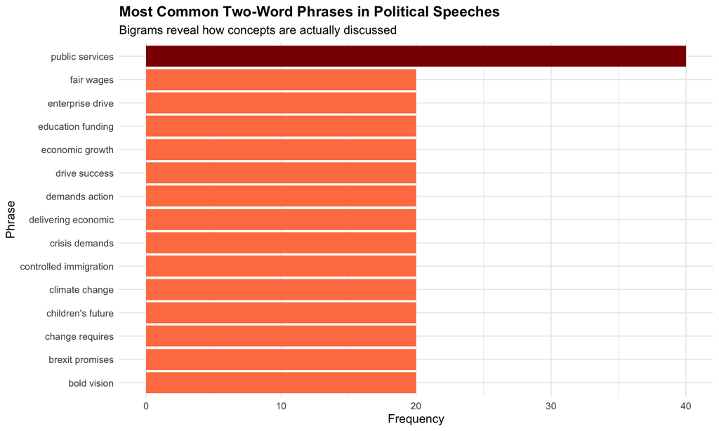

```r
# Visualize top bigrams
bigram_counts %>%
  head(15) %>%
  mutate(bigram = reorder(bigram, n)) %>%
  ggplot(aes(x = bigram, y = n, fill = n)) +
  geom_col(show.legend = FALSE) +
  coord_flip() +
  scale_fill_gradient(low = "coral", high = "darkred") +
  theme_minimal(base_size = 12) +
  labs(
    title = "Most Common Two-Word Phrases in Political Speeches",
    subtitle = "Bigrams reveal how concepts are actually discussed",
    x = "Phrase",
    y = "Frequency"
  ) +
  theme(plot.title = element_text(face = "bold"))
```

# Technical Skills Demonstrated

Through these analyses, I’ve demonstrated:

## **Data Processing**

- Text cleaning and preprocessing
- Tokenization (words and n-grams)
- Stop word removal
- Data reshaping for text analysis

## **Analytical Methods**

- **Frequency analysis**: Identifying most common terms
- **Sentiment analysis**: Using lexicon-based methods to quantify emotional tone
- **Comparative analysis**: Contrasting text across different sources
- **N-gram analysis**: Examining multi-word phrases

## **Visualization Techniques**

- Bar charts for frequency distributions
- Faceted plots for cross-group comparisons
- Word clouds for intuitive term visualization
- Timeline plots for sentiment trajectories

## **R Packages Used**

- `tidytext` - Tidy text mining
- `textdata` - Sentiment lexicons
- `ggwordcloud` - Word cloud visualizations
- `tidyverse` - Data manipulation and visualization

# Applications in Political Science

Text analysis methods like these have important applications:

1. **Legislative Analysis**: Examining bills, amendments, and parliamentary debates to understand policy priorities
2. **Media Analysis**: Studying news coverage and framing of political events
3. **Social Media Research**: Analyzing Twitter/X discourse around elections and policy issues
4. **Historical Research**: Comparing political rhetoric across different eras
5. **Campaign Analysis**: Understanding messaging strategies and effectiveness

# Methodological Considerations

**Strengths of text analysis:** - Enables analysis of massive text corpora - Provides quantitative measures of qualitative content - Reveals patterns invisible to manual reading - Reproducible and transparent

**Limitations to acknowledge:** - Sentiment lexicons may miss context and sarcasm - Single-word analysis can miss meaning in phrases - Requires careful interpretation alongside domain knowledge - Results depend on text quality and preprocessing choices

**Best practices:** - Always examine your text data qualitatively first - Use multiple sentiment lexicons to check robustness - Consider context - a word’s meaning varies by domain - Combine text analysis with other research methods

# Code Repository

All code for this text analysis is available in my [GitHub repository](https://github.com/erahemzadh/eiliya-gv300-website).

The analysis demonstrates: - Clean, well-commented R code - Reproducible workflow with R Markdown - Professional visualizations - Clear interpretation of results

# Further Reading

To learn more about text analysis in R:

- [Text Mining with R](https://www.tidytextmining.com/) by Julia Silge and David Robinson
- [Quanteda tutorials](https://tutorials.quanteda.io/) for advanced text analysis
- [Speech and Language Processing](https://web.stanford.edu/~jurafsky/slp3/) by Jurafsky and Martin

*This showcase demonstrates computational text analysis skills developed as part of my GV300 coursework and independent study. All analysis uses open-source R packages and follows reproducible research principles.*

**← Back to Portfolio** | **View Quantitative Analysis →**